# Stocks

Cameron Collett

March 22, 2018

```r
# Use this R-Chunk to import all your datasets!

#This is for my data. I chose Nike, Bic, and Bitcoin

returns <- c("NKE", "BB", "BTSC") %>%
  tq_get(get  = "stock.prices",
         from = "2017-10-01",
         to   = "2018-03-05") %>%
  group_by(symbol) %>%
  mutate(travelsum = cumsum(adjusted),
         dailychange = close - open)

#This is for my friend. He chose Life Time Fitness, Walmart and FedEx.

friend <- c("LTM", "WMT", "FDX") %>%
  tq_get(get  = "stock.prices",
         from = "2017-10-01",
         to   = "2018-03-05") %>%
  group_by(symbol) %>%
  mutate(travelsum = cumsum(adjusted),
         dailychange = close - open)
```

## Background

My friend and I have invested $1000 in 3 separate companies each and are recording how we’ve done since we invested in October. I invested into

- Nike - NKE
- BIC - BB
- Bitcoin - BRSC

My friend invested in

- Walmart - WMT
- FedEx - FDX
- Life Time Fitness - LTM

## Data Wrangling

```r
# Use this R-Chunk to clean & wrangle your data!
```

## Data Visualization

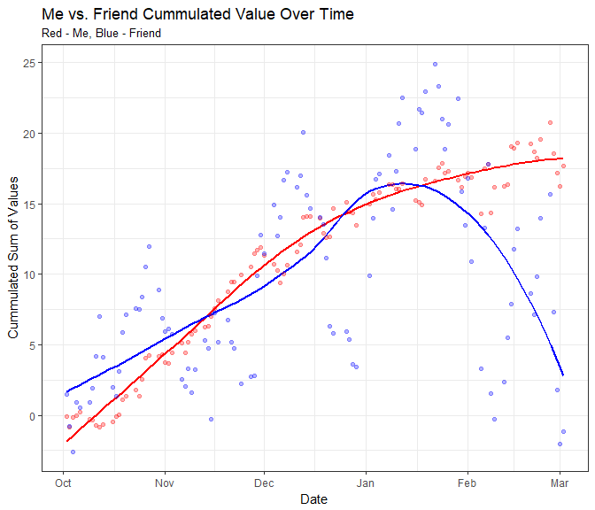

```r
mine <- returns %>%
  group_by(date) %>%
  summarise(score = as.numeric(sum(dailychange))) %>%
  ungroup() %>%
  mutate(date = ymd(date),
    travelingsum = cumsum(score))

his <- friend %>%
  group_by(date) %>%
  summarise(score = as.numeric(sum(dailychange))) %>%
  ungroup() %>%
  mutate(date = ymd(date),
         travelingsum = cumsum(score))

mysmooth <- geom_smooth(data = mine, aes(x = date, y = travelingsum), se = FALSE, color = "red")
hissmooth <- geom_smooth(data = his, aes(x = date, y = travelingsum), se = FALSE, color = "blue")

ggplot() +
  mysmooth +
  hissmooth +
  geom_point(data = mine, aes(x = date, y = travelingsum), alpha = 0.3, color = "red") +
  geom_point(data = his, aes(x = date, y = travelingsum), alpha = 0.3, color = "blue") +
#+geom_line(data = mine, aes(x = date, y = travelingsum), alpha = 0.3, color = "red") +
  #geom_line(data = his, aes(x = date, y = travelingsum), alpha = 0.3, color = "blue")
  labs(x = "Date",
       y = "Cummulated Sum of Values",
       title = "Me vs. Friend Cummulated Value Over Time",
       subtitle = "Red - Me, Blue - Friend") +
  theme_bw()
```

```r
#ggplot() +
 # geom_point(data = mine, aes(x = date, y = travelingsum), color = "blue") +
  #geom_smooth(data = mine, aes(x = date, y = travelingsum))

#ggplot() +
 # geom_point(data = his, aes(x = date, y = travelingsum), color = "red") +
  #geom_smooth(data = his, aes(x = date, y = travelingsum))
```

We see that my friend is being faced with misfortune as his value dips almost all the way down to where it was in October. I seem to have a steady increase but am leveling out. I obviously did better than my friend.

## Graphics

In the first plots, we have the values of the stocks for the companies plotted against eachother. In the second plots, we see the change in the value of the stock each day. A wide spread of data on the Y axis represents a higher risk because the stock may be worth more, but it can also looks just as much value.